# Tennis4_WIT

It is the 4th part of our ATP journey!!

To check how I prepared the dataset, please check my other notebook: [Tennis Part 2: Modelization & Prediction](https://www.kaggle.com/danielfmfurlan/tennis-part-2-modelization-prediction).

For Explainability, check the [3rd part](https://www.kaggle.com/danielfmfurlan/tennis-part3-machine-learning-explainability)

This time we'll compare 2 models performance on the ATP dataset!!

To do so, we will use the [What-if-Tool](https://pair-code.github.io/what-if-tool/) a very cool interface where we can see in real-time what would happen "if" we make some change in the data!

The models are a Linear Classifier and a DNN.

```python
!pip install PyDrive
```

```python
from pydrive.auth import GoogleAuth
from pydrive.drive import GoogleDrive
from google.colab import auth
from oauth2client.client import GoogleCredentials
```

```python
auth.authenticate_user()
gauth = GoogleAuth()
gauth.credentials = GoogleCredentials.get_application_default()
drive = GoogleDrive(gauth)
```

```python
downloaded = drive.CreateFile({'id':"1cux_cycrlsO9pYufdOPFe6GOM-ojodP2"})   # replace the id with id of file you want to access
downloaded.GetContentFile('data_model4_wit_swap.csv')
```

```python
try:
  import google.colab
  !pip install --upgrade witwidget
except:
  pass

# https://drive.google.com/file/d/1cux_cycrlsO9pYufdOPFe6GOM-ojodP2/view?usp=sharing

# 1cux_cycrlsO9pYufdOPFe6GOM-ojodP2
```

```python
import pandas as pd
df = pd.read_csv('/content/data_model4_wit_swap.csv', index_col = 0)
df.head()
```

|  | ATP | Location | Tournament | Date | Series | Court | Surface | Round | Best of | WPts | LPts | Labels | Player1 | Oponent | winner_WRank | loser_LRank |
| --- | --- | --- | --- | --- | --- | --- | --- | --- | --- | --- | --- | --- | --- | --- | --- | --- |
| 0 | 1 | Adelaide | Australian Hardcourt Championships | 2000-01-03 | International | Outdoor | Hard | 1st Round | 3 | 16950.0 | 16950.0 | 1 | Dosedel S. | Ljubicic I. | 63.0 | 77.0 |
| 1 | 1 | Adelaide | Australian Hardcourt Championships | 2000-01-03 | International | Outdoor | Hard | 1st Round | 3 | 16950.0 | 16950.0 | 0 | Clement A. | Enqvist T. | 56.0 | 5.0 |
| 2 | 1 | Adelaide | Australian Hardcourt Championships | 2000-01-03 | International | Outdoor | Hard | 1st Round | 3 | 16950.0 | 16950.0 | 0 | Baccanello P. | Escude N. | 655.0 | 40.0 |
| 3 | 1 | Adelaide | Australian Hardcourt Championships | 2000-01-03 | International | Outdoor | Hard | 1st Round | 3 | 16950.0 | 16950.0 | 1 | Federer R. | Knippschild J. | 65.0 | 87.0 |
| 4 | 1 | Adelaide | Australian Hardcourt Championships | 2000-01-03 | International | Outdoor | Hard | 1st Round | 3 | 16950.0 | 16950.0 | 1 | Fromberg R. | Woodbridge T. | 81.0 | 198.0 |

```python
import pandas as pd
import numpy as np
import tensorflow as tf
import functools
#df = pd.read_csv("/content/sample_data/data_model4_wit_swap.csv",index_col=0,skipinitialspace=True)
```

```python
# Creates a tf feature spec from the dataframe and columns specified.
def create_feature_spec(df, columns=None):
    feature_spec = {}
    if columns == None:
        columns = df.columns.values.tolist()
    for f in columns:
        if df[f].dtype is np.dtype(np.int64):
            feature_spec[f] = tf.io.FixedLenFeature(shape=(), dtype=tf.int64)
        elif df[f].dtype is np.dtype(np.float64):
            feature_spec[f] = tf.io.FixedLenFeature(shape=(), dtype=tf.float32)
        else:
            feature_spec[f] = tf.io.FixedLenFeature(shape=(), dtype=tf.string)
    return feature_spec

# Creates simple numeric and categorical feature columns from a feature spec and a
# list of columns from that spec to use.
#
# NOTE: Models might perform better with some feature engineering such as bucketed
# numeric columns and hash-bucket/embedding columns for categorical features.
def create_feature_columns(columns, feature_spec):
    ret = []
    for col in columns:
        if feature_spec[col].dtype is tf.int64 or feature_spec[col].dtype is tf.float32:
            ret.append(tf.feature_column.numeric_column(col))
        else:
            ret.append(tf.feature_column.indicator_column(
                tf.feature_column.categorical_column_with_vocabulary_list(col, list(df[col].unique()))))
    return ret

# An input function for providing input to a model from tf.Examples
def tfexamples_input_fn(examples, feature_spec, label, mode=tf.estimator.ModeKeys.EVAL,
                       num_epochs=None,
                       batch_size=64):
    def ex_generator():
        for i in range(len(examples)):
            yield examples[i].SerializeToString()
    dataset = tf.data.Dataset.from_generator(
      ex_generator, tf.dtypes.string, tf.TensorShape([]))
    if mode == tf.estimator.ModeKeys.TRAIN:
        dataset = dataset.shuffle(buffer_size=2 * batch_size + 1)
    dataset = dataset.batch(batch_size)
    dataset = dataset.map(lambda tf_example: parse_tf_example(tf_example, label, feature_spec))
    dataset = dataset.repeat(num_epochs)
    return dataset

# Parses Tf.Example protos into features for the input function.
def parse_tf_example(example_proto, label, feature_spec):
    parsed_features = tf.io.parse_example(serialized=example_proto, features=feature_spec)
    target = parsed_features.pop(label)
    return parsed_features, target

# Converts a dataframe into a list of tf.Example protos.
def df_to_examples(df, columns=None):
    examples = []
    if columns == None:
        columns = df.columns.values.tolist()
    for index, row in df.iterrows():
        example = tf.train.Example()
        for col in columns:
            if df[col].dtype is np.dtype(np.int64):
                example.features.feature[col].int64_list.value.append(int(row[col]))
            elif df[col].dtype is np.dtype(np.float64):
                example.features.feature[col].float_list.value.append(row[col])
            elif row[col] == row[col]:
                example.features.feature[col].bytes_list.value.append(row[col].encode('utf-8'))
        examples.append(example)
    return examples

# Converts a dataframe column into a column of 0's and 1's based on the provided test.
# Used to force label columns to be numeric for binary classification using a TF estimator.
#def make_label_column_numeric(df, label_column, test):
 # df[label_column] = np.where(test(df[label_column]), 1, 0)
```

```python
df.columns
```

```
Index(['ATP', 'Location', 'Tournament', 'Date', 'Series', 'Court', 'Surface',
       'Round', 'Best of', 'WPts', 'LPts', 'Labels', 'Player1', 'Oponent',
       'winner_WRank', 'loser_LRank'],
      dtype='object')
```

```python
df.rename(columns={"Best of":"BestOf"},inplace=True)
```

```python
import numpy as np

# Set the column in the dataset you wish for the model to predict
label_column = 'Labels'

#make_label_column_numeric(df, label_column, lambda val: val == '1')

# Set list of all columns from the dataset we will use for model input.
input_features = [
  'ATP', 'Location', 'Tournament', 'Date', 'Series', 'Court', 'Surface',
       'Round', 'BestOf', 'winner_WRank', 'loser_LRank', 'WPts', 'LPts',
       'Player1', 'Oponent']

# Create a list containing all input features and the label column
features_and_labels = input_features + [label_column]
```

```python
### Converting dataset to tf.Proto

examples = df_to_examples(df)
```

```python
#Create and train the linear classifier

num_steps = 2000

# Create a feature spec for the classifier
feature_spec = create_feature_spec(df, features_and_labels)

# Define and train the classifier
train_inpf = functools.partial(tfexamples_input_fn, examples, feature_spec, label_column)
classifier = tf.estimator.LinearClassifier(
    feature_columns=create_feature_columns(input_features, feature_spec))
classifier.train(train_inpf, steps=num_steps)
```

```python
#Create and train the DNN classifier
num_steps_2 = 2000

classifier2 = tf.estimator.DNNClassifier(
    feature_columns=create_feature_columns(input_features, feature_spec),
    hidden_units=[128, 64, 32])
classifier2.train(train_inpf, steps=num_steps_2)
```

I will now get the very 10% last of our dataset to make it the test as I usually split the data into 80,10,10% (train,valid,test)

And now lets the magic flow!! =)

```python
#Invoke What-If Tool

num_datapoints = 2000
tool_height_in_px = 1000

from witwidget.notebook.visualization import WitConfigBuilder
from witwidget.notebook.visualization import WitWidget

test_df = df.iloc[-5229:]

#make_label_column_numeric(test_df, label_column, lambda val: val == '>50K.')
test_examples = df_to_examples(test_df[0:num_datapoints])

# Setup the tool with the test examples and the trained classifier
config_builder = WitConfigBuilder(test_examples[0:num_datapoints]).set_estimator_and_feature_spec(
    classifier, feature_spec).set_compare_estimator_and_feature_spec(
    classifier2, feature_spec).set_label_vocab(['0', '1'])
a = WitWidget(config_builder, height=tool_height_in_px)
```

[figure not shown]

If you cannot play with the features, take a look the images below:

Wow!! He can explore a lot of things here!!

The very first graph that it plots is not that helpful to understand the model differences as it colors it with "inference value 1", that is to say, the blue are the samples that model 1 predicted as 0 and the red are the samples that model 1 predicted as 1 (the "1" at "inference value 1" doesn't correspond to the labels but to the model number!)

Lets play with some configurations!

Change the tabs as follows:

- Bimming X : inference correct 1 (LC)
- Bimming Y : inference correct 2 (DNN)
- Color by : inference value 1 (model 1)

Doing so, you'll get 4 plans: "correct" & "incorrect" predictions for both models (separetedly)

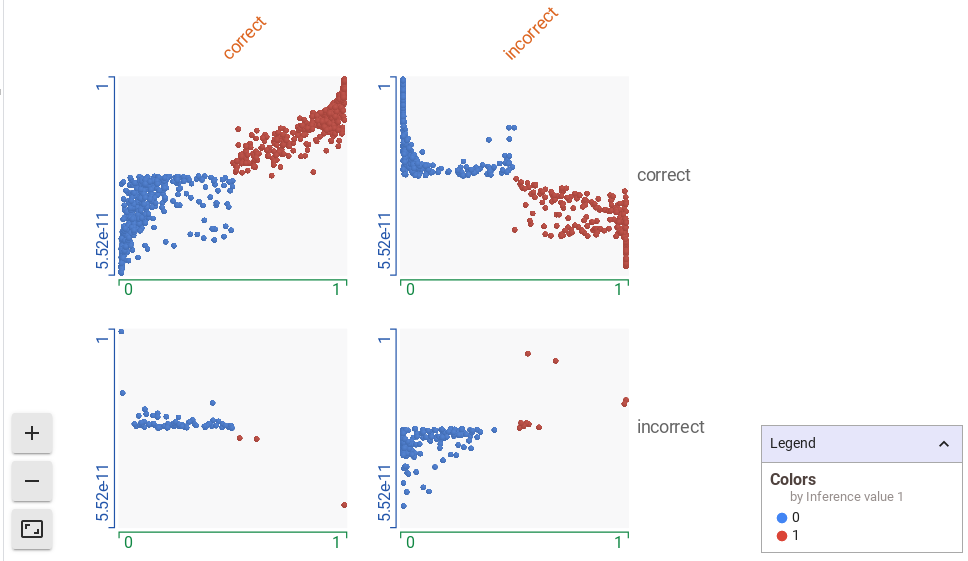

Now try to get an incorrect prediction from the model 1 and change the "WRank" value on the left pannel. See what happens with the predictions if you put a very good rank (say, 1). It can happen that model 1 can better predict it than model 2 (as in my case) as the LC can do straight-foward assumptions on important features (like "WRank" and "LRank").

And if you change the "loser_LRank" or "winer_WRank" value of some point?

1. Bimming X: datapoint ID
2. Color by: inference correct 1 (LC)

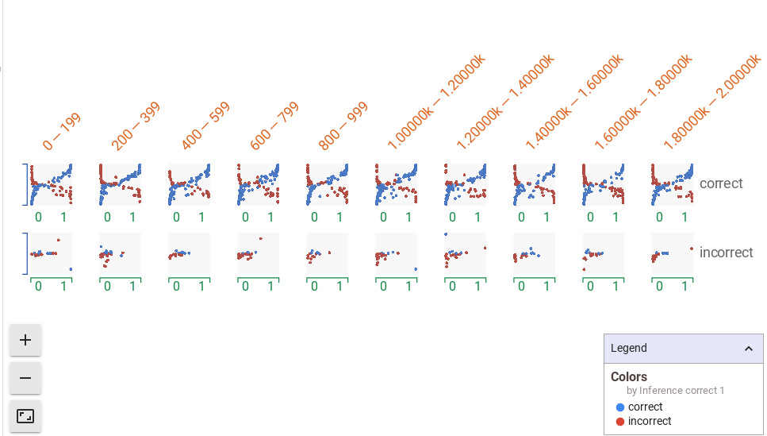

It seems that the model 1 had the worst performance on the 9th percentile of the test data (1600-1800 sampes)

1. Bimming X : datapoint ID
2. Bimming Y : inference correct 1 (LC)
3. Color by: inference correct 2 (DNN)

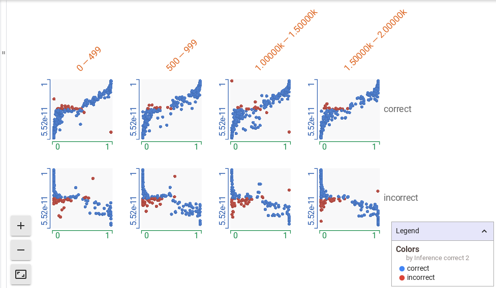

The most incorrect values from model 2 are also present on the incorrect predicitons of model 1 but very few incorrect values predicted from model 2 were corrected predicted by model 1 (try to put the Bimming Y to "inference correct 2" and you see also that only very few mis prediction from model 2 were if "high" confidence, that is to say, the most part of incorrect predictions the model was not very "sure" about its predictions - score always near 0.5 the threshold)

Finally, take a look at the performance of both models: (model 2 was way better than the 1, right?)

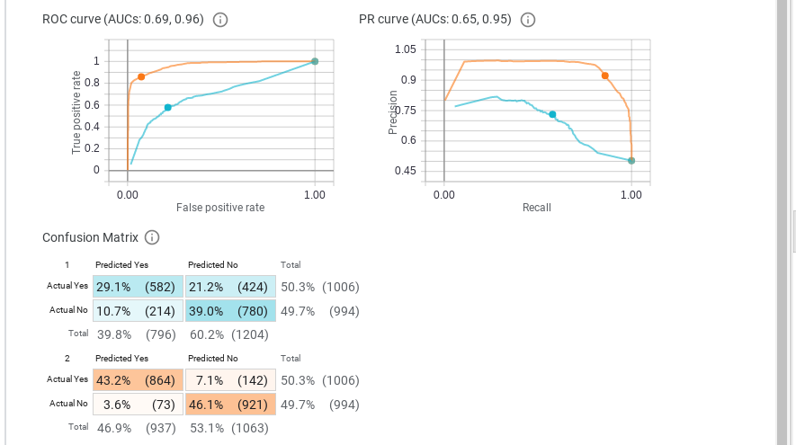